# Kontraste_mehrfaktoriell

Neele Engelmann

22 Juni 2020

Daten einlesen und Pakete laden

```r
#Daten
library(readr)
data <- read_delim("Glastonbury.csv", ";", escape_double = FALSE, trim_ws = TRUE)

#Commander
library(Rcmdr)
```

“music” zum Faktor definieren

```r
# auf richtige Schreibweise der levels achten (groß, klein, Leerzeichen)
data$music <- factor(data$music,levels=c("Crusty","Indie Kid","Metaller","No Musical Affiliation"))

# prüfen, ob levels richtig definiert wurden und in welcher Reihenfolge sie sind
levels(data$music)
```

```
## [1] "Crusty"                 "Indie Kid"              "Metaller"
## [4] "No Musical Affiliation"
```

Grafik erstellen im commander (Kriterium: day1)

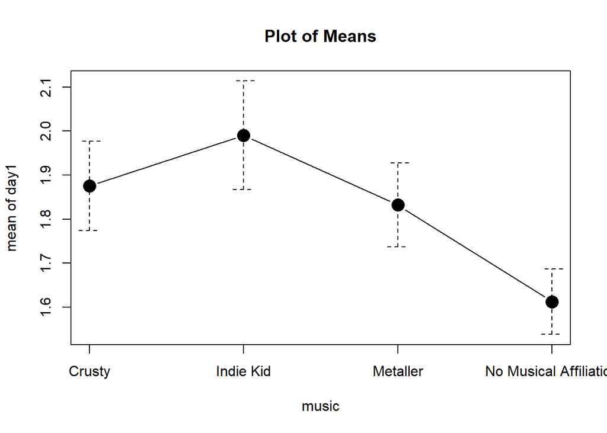

```r
with(data, plotMeans(day1, music, error.bars="conf.int", level=0.95, connect=TRUE))
```

Helmert-Kontraste anlegen im Commander

```r
contrasts(data$music) <- "contr.helmert"
```

Prüfen, welche Kontrastkoeffizienten dadurch angelegt wurden:

```r
contrasts(data$music)
```

```
##                        [,1] [,2] [,3]
## Crusty                   -1   -1   -1
## Indie Kid                 1   -1   -1
## Metaller                  0    2   -1
## No Musical Affiliation    0    0    3
```

Wann immer ein Kontrastkoeffizient 0 ist, geht der entsprechende Mittelwert **nicht** in den Vergleich ein. Koeffizienten mit positivem Vorzeichen werden immer mit Koeffizienten mit negativem Vorzeichen verglichen.

- 3 ist also No Musical Affiliation vs. [Crusty, Indie, Metal]
- 2 ist Metal vs. [Crusty, Indie]
- 1 ist Indie vs. Crusty

Da “No Affiliation” sich laut Graph von allen anderen Gruppen zu unterscheiden scheint und auch inhaltlich als eine Art Baseline-Gruppe gesehen werden kann, können wir die Anordnung so lassen. Falls man sich inhaltlich mehr dafür interessiert, ob sich eine der anderen Gruppen von allen anderen unterscheidet, sollte man die Faktorstufen neu anordnen und diese Gruppe an die letzte Stelle setzen.

Mit dem Code, mit dem wir oben auch den character-Vektor zum Faktor gemacht haben, könnten wir ihn auch erneut überschreiben und die Reihenfolge der levels ändern (hier auskommentiert, weil wir gleich mit den eben angelegten levels weiterrechnen wollen):

```r
#Beispiel: "Crusty" nach hinten stellen
#data$music <- factor(data$music,levels=c("No Musical Affiliation","Indie Kid","Metaller","Crusty"))
```

**Rechnen des linearen Modells mit den definierten Kontrasten**:

```r
KontrastModell_Helmert <- lm(day1 ~ music, data=data)

summary(KontrastModell_Helmert)
```

```
##
## Call:
## lm(formula = day1 ~ music, data = data)
##
## Residuals:
##      Min       1Q   Median       3Q      Max
## -1.82536 -0.46906  0.00884  0.45797  2.07715
##
## Coefficients:
##             Estimate Std. Error t value Pr(>|t|)
## (Intercept)  1.82763    0.02611  69.986  < 2e-16 ***
## music1       0.05747    0.04160   1.381    0.168
## music2      -0.03360    0.02197  -1.529    0.127
## music3      -0.07160    0.01233  -5.806 9.21e-09 ***
## ---
## Signif. codes:  0 '***' 0.001 '**' 0.01 '*' 0.05 '.' 0.1 ' ' 1
##
## Residual standard error: 0.6803 on 806 degrees of freedom
## Multiple R-squared:  0.04139,    Adjusted R-squared:  0.03782
## F-statistic:  11.6 on 3 and 806 DF,  p-value: 1.896e-07
```

**Interpretation des Outputs**:

- Intercept: Mittelwert der Mittelwerte
- Estimates: Beziehen sich auf die durch die Kontrastkoeffizienten kodierten Vergleiche (wenn größer, dann stärkerer Unterschied zwischen den entsprechenden Gruppen). (Sind hier aber nicht identisch mit den entsprechenden Mittelwertsdifferenzen.)
- Rest des Modells (Residuen, R-Squared, F-Test): Zu interpretieren wie immer (Vergleich zum Nullmodell)

**Interpretation der Estimates im Detail (siehe VL Kontraste Folie 15)**

(Dieser Teil ist Zusatz fürs Verständnis, den Code müsst ihr nicht selbst schreiben können.)

Zur Veranschaulichung legen wir erstmal die Kontrast-Dummy-Variablen sichtbar im Datensatz an (nur damit wir sie nochmal sehen können)

```r
#Zur Erinnerung: wie müssen wir die Koeffizienten vergeben, um die oben im Commander angelegten Kontraste zu reproduzieren?
contrasts(data$music)
```

```
##                        [,1] [,2] [,3]
## Crusty                   -1   -1   -1
## Indie Kid                 1   -1   -1
## Metaller                  0    2   -1
## No Musical Affiliation    0    0    3
```

```r
#Erster Kontrast: -1 wenn Crusty, 1 wenn Indie Kid, ansonsten 0 (die ifelse-Funktion ist sehr ähnlich aufgebaut wie die "wenn"-Funktion in Excel)
data$music1 <- ifelse(data$music=="Crusty",-1,
                      ifelse(data$music=="Indie Kid",1,0))

#Zweiter Kontrast: -1 wenn Crusty oder Indie Kid, 2 wenn Metaller, sonst 0
data$music2 <- ifelse(data$music=="Crusty"|data$music=="Indie Kid",-1,
                      ifelse(data$music=="Metaller",2,0))

#Dritter Kontrast: 3 wenn No Musical Affiliation, sonst -1
data$music3 <- ifelse(data$music=="No Musical Affiliation",3,-1)

#Datensatz ansehen
View(data)
```

Kurzer Check: lineares Modell mit den eben angelegten Kontrasten sollte gleiches Ergebnis liefern wie Helmert-Kontraste über commander

```r
summary(lm(day1~music1+music2+music3,data=data))
```

```
##
## Call:
## lm(formula = day1 ~ music1 + music2 + music3, data = data)
##
## Residuals:
##      Min       1Q   Median       3Q      Max
## -1.82536 -0.46906  0.00884  0.45797  2.07715
##
## Coefficients:
##             Estimate Std. Error t value Pr(>|t|)
## (Intercept)  1.82763    0.02611  69.986  < 2e-16 ***
## music1       0.05747    0.04160   1.381    0.168
## music2      -0.03360    0.02197  -1.529    0.127
## music3      -0.07160    0.01233  -5.806 9.21e-09 ***
## ---
## Signif. codes:  0 '***' 0.001 '**' 0.01 '*' 0.05 '.' 0.1 ' ' 1
##
## Residual standard error: 0.6803 on 806 degrees of freedom
## Multiple R-squared:  0.04139,    Adjusted R-squared:  0.03782
## F-statistic:  11.6 on 3 and 806 DF,  p-value: 1.896e-07
```

Das statistische Modell ist also:

y =beta0 + beta1 x music1 + beta2 x music2 + beta3 x music3